# R Notebook

# Opening Files

```r
library(brms)
library(readxl)
library(rmarkdown)
library(tidybayes)
library(ggplot2)
library(tidyr)
library(dplyr)
library(GGally)
library(ggpubr)
library(tidybayes)
library(patchwork)
library(sjPlot)
library(lubridate)
library(zoo)
```

```r
DOD_42mo <- read_xlsx("DOD_42mo_blind.xlsx")
N_total <- nrow(DOD_42mo) # sanity check
```

Create mismatch variables. I’m also creating some character versions of many factors to make plotting a bit easier later.

```r
DOD_42mo <- DOD_42mo %>%
 mutate(
    Prime = ifelse(Prime.Type==.5, yes="DOD", no="POD"), # Prime type, character version
    Overlap = ifelse(Verb.match==.5, yes="Overlap", no="No Overlap") # overlap
    )

DOD_42mo$bias <-"DOD" # set as DOD bias
DOD_42mo$bias[DOD_42mo$Prime.verb=="passed"] = "POD" # Change POD-biased prime verbs.
DOD_42mo$bias[DOD_42mo$Prime.verb=="sent"] = "POD"
DOD_42mo$bias[DOD_42mo$Prime.verb=="threw"] = "POD"

DOD_42mo$biasmatch <-"match" # set to match

DOD_42mo$biasmatch[DOD_42mo$bias=="POD" & DOD_42mo$Prime == "DOD"] = "mismatch" # Change to mismatch.
DOD_42mo$biasmatch[DOD_42mo$bias=="DOD" & DOD_42mo$Prime == "POD"] = "mismatch"

table(DOD_42mo$biasmatch)
```

```
   match mismatch
     541      539
```

```r
DOD_42mo$biasmismatchc <- ifelse(DOD_42mo$biasmatch == "mismatch", yes=.5, no=-.5)
```

# Missing data

There is one type of trial coded as an admin error that I don’t want to remove at the time being – trials 7r on lists 6 and 8.

```r
DOD_42mo <- DOD_42mo %>%
  mutate(
    Trial_Drop = ifelse(is.na(RESPONSE.CODE), yes=1, no=0)
  )

N_miss <- DOD_42mo %>%
  filter(is.na(RESPONSE.CODE)) %>%
  nrow()
```

```r
DOD_42mo %>%
  summarise(
    Verb_Error = sum(Verb.error, na.rm=TRUE),
    Admin_Error = sum(Admin.error, na.rm=TRUE),
    Prompts.disallowed = sum(Prompts.disallowed, na.rm=TRUE),
    Prep_Error = sum(Prep.error.bin, na.rm=TRUE),
    Reversal_Error = sum(Reversal.error, na.rm=TRUE),
    NonTargetResponse = sum(NonTarget.response, na.rm=TRUE),
    No_Response = sum(No.response, na.rm=TRUE),
    GavePOD = sum(Gave.POD, na.rm=TRUE)
     )
```

| Verb_Error | Admin_Error | Prompts.disallowed | Prep_Error | Reversal_Error | NonTargetResponse | No_Response | GavePOD |
| --- | --- | --- | --- | --- | --- | --- | --- |
| 26 | 10 | 57 | 72 | 3 | 216 | 11 | 12 |

```r
NA
NA
```

216 non-target responses (this includes lots of stuff, non-dative responses, preposition errors, etc).

```r
DOD_42mo %>%
 filter(is.na(NonTarget.response) & is.na(RESPONSE.CODE)) %>%
  summarise(
    Verb_Error = sum(Verb.error, na.rm=TRUE),
    Admin_Error = sum(Admin.error, na.rm=TRUE),
    Prompts.disallowed = sum(Prompts.disallowed, na.rm=TRUE),
    Prep_Error = sum(Prep.error.bin, na.rm=TRUE),
    Reversal_Error = sum(Reversal.error, na.rm=TRUE),
    NonTargetResponse = sum(NonTarget.response, na.rm=TRUE),
    No_Response = sum(No.response, na.rm=TRUE),
    GavePOD = sum(Gave.POD, na.rm=TRUE)
     )
```

| Verb_Error | Admin_Error | Prompts.disallowed | Prep_Error | Reversal_Error | NonTargetResponse | No_Response | GavePOD |
| --- | --- | --- | --- | --- | --- | --- | --- |
| 15 | 7 | 1 | 0 | 0 | 0 | 0 | 0 |

```r
NA
```

15 verb errors, 7 admin errors 1 disallowed prompt = 23.

See how many missing values we have by participant

```r
DOD_42mo %>%
  group_by(Blind_ID) %>%
  mutate(
    N_Missing = sum(is.na(RESPONSE.CODE))
  ) %>%
  slice(1) %>%
  select("Blind_ID", "N_Missing") %>%
  group_by(N_Missing) %>%
  count()
```

| N_Missing | n |
| --- | --- |
| 0 | 25 |
| 1 | 19 |
| 2 | 16 |
| 3 | 9 |
| 4 | 3 |
| 5 | 1 |
| 6 | 6 |
| 8 | 4 |
| 9 | 1 |
| 10 | 2 |

[output cut: 2 more lines]

```r
DOD_42mo <- DOD_42mo %>%
  group_by(Blind_ID) %>%
  mutate(
    N_Missing = sum(is.na(RESPONSE.CODE))
  ) %>%
  slice(1) %>%
  select("Blind_ID", "N_Missing") %>%
  mutate(
    Drop = ifelse(N_Missing >= 10, 1, 0),
    MightDrop = ifelse(N_Missing > 6, 1, 0)
  ) %>%
  full_join(DOD_42mo, .)
N_drop = DOD_42mo %>%
  filter(Drop == 1 & !is.na(RESPONSE.CODE)) %>%
  count()
```

```r
DOD_42mo %>%
  group_by(Target.verb) %>%
  mutate(
    N_Missing = sum(is.na(RESPONSE.CODE))
  ) %>%
  slice(1) %>%
  select("Target.verb", "N_Missing") %>%
  group_by(Target.verb)
```

| Target.verb | N_Missing |
| --- | --- |
| brought | 41 |
| gave | 38 |
| passed | 33 |
| push | 2 |
| pushed | 1 |
| putting | 1 |
| rolled | 1 |
| sent | 31 |
| showed | 45 |
| threw | 45 |

[output cut: 1 more lines]

All non-target verbs have been removed. It doesn’t make sense to estimate random effects for a level of a random factor with only a single observation.

And let’s just check the proportion of missing trials across the various experimental conditions.

```r
DOD_42mo %>%
  mutate(
    Missing = ifelse(is.na(RESPONSE.CODE), yes=1, no = 0)
  ) %>%
  group_by(Prime, Overlap) %>%
  summarise(
    mean = mean(Missing),
    sd = sd(Missing)
  )
```

| Prime | Overlap | mean | sd |
| --- | --- | --- | --- |
| DOD | No Overlap | 0.2500000 | 0.4338478 |
| DOD | Overlap | 0.2186380 | 0.4140651 |
| POD | No Overlap | 0.2528736 | 0.4354942 |
| POD | Overlap | 0.1678571 | 0.3744086 |

```r
DOD_42mo %>%
  mutate(
    Missing = ifelse(is.na(RESPONSE.CODE), yes=1, no = 0)
  ) %>%
  group_by(Prime, biasmatch) %>%
  summarise(
    mean = mean(Missing),
    sd = sd(Missing)
  )
```

| Prime | biasmatch | mean | sd |
| --- | --- | --- | --- |
| DOD | match | 0.2481481 | 0.4327404 |
| DOD | mismatch | 0.2193309 | 0.4145645 |
| POD | match | 0.1992620 | 0.4001845 |
| POD | mismatch | 0.2185185 | 0.4140085 |

```r
DOD_42mo <- filter(DOD_42mo, !is.na(RESPONSE.CODE) & Drop==0) # 836

nrow(DOD_42mo) == N_total - N_miss - N_drop
```

```
        n
[1,] TRUE
```

```r
DOD_42mo %>%
  summarise(
    min = min(Session.Age),
    max = max(Session.Age)
  )
```

| min | max |
| --- | --- |
| 41 : 27 | 43 : 5 |

```r
NA
NA
```

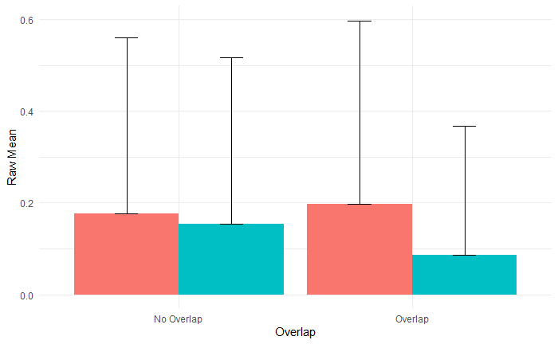

```r
(p1 <- DOD_42mo %>%
  group_by(Prime, Overlap) %>%
  summarise(mean = mean(RESPONSE.CODE, na.rm=TRUE),
            sd = sd(RESPONSE.CODE, na.rm=TRUE)) %>%

ggplot(aes(y=mean, x=Overlap, fill=Prime)) +
  geom_bar(stat="identity",position="dodge") +
 geom_errorbar(aes(ymin=mean, ymax=mean+sd), width=.2,
                 position=position_dodge(.9)) +
  ylim(0, .6) +
  theme_minimal() +
  labs(y="Raw Mean") +
  theme(legend.position = "none")
)
```

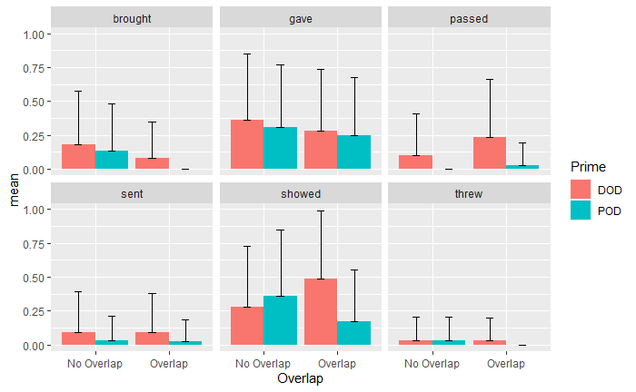

```r
DOD_42mo %>%
  group_by(Prime, Overlap, Target.verb) %>%
  summarise(mean = mean(RESPONSE.CODE, na.rm=TRUE),
            sd = sd(RESPONSE.CODE, na.rm=TRUE)) %>%

ggplot(aes(y=mean, x=Overlap, fill=Prime)) +
  geom_bar(stat="identity",position="dodge") +
 geom_errorbar(aes(ymin=mean, ymax=mean+sd), width=.2,
                 position=position_dodge(.9)) +
  facet_wrap(~Target.verb)
```

And let’s look at the pattern of responses when we only consider participants who produced at least 1 DOD.

```r
DOD_42mo <- DOD_42mo %>%
  group_by(Blind_ID) %>%
  mutate(
    Prod_DOD = sum(RESPONSE.CODE)
  ) %>%
  dplyr::select(Blind_ID, Prod_DOD) %>%
  slice(1) %>%
  ungroup() %>%
  full_join(DOD_42mo, ., by="Blind_ID")
```

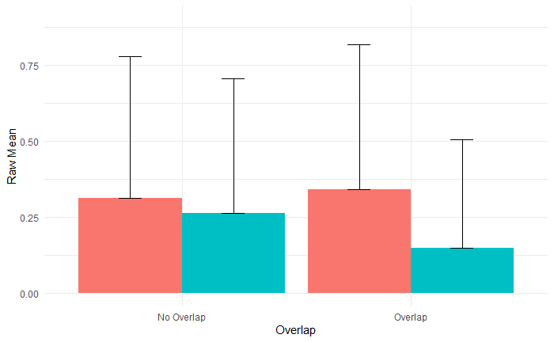

```r
DOD_42mo2 <- filter(DOD_42mo, Prod_DOD > 0)

(p1b <- DOD_42mo2 %>%
  group_by(Prime, Overlap) %>%
  summarise(mean = mean(RESPONSE.CODE, na.rm=TRUE),
            sd = sd(RESPONSE.CODE, na.rm=TRUE)) %>%

ggplot(aes(y=mean, x=Overlap, fill=Prime)) +
  geom_bar(stat="identity",position="dodge") +
 geom_errorbar(aes(ymin=mean, ymax=mean+sd), width=.2,
                 position=position_dodge(.9)) +
  ylim(0, .9) +
  theme_minimal() +
  labs(y="Raw Mean") +
  theme(legend.position = "none")
)
```

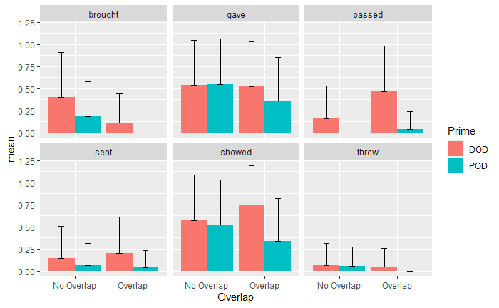

```r
DOD_42mo2 %>%
  group_by(Prime, Overlap, Target.verb) %>%
  summarise(mean = mean(RESPONSE.CODE, na.rm=TRUE),
            sd = sd(RESPONSE.CODE, na.rm=TRUE)) %>%

ggplot(aes(y=mean, x=Overlap, fill=Prime)) +
  geom_bar(stat="identity",position="dodge") +
 geom_errorbar(aes(ymin=mean, ymax=mean+sd), width=.2,
                 position=position_dodge(.9)) +
  facet_wrap(~Target.verb)
```

Maybe a bit different for **brought** but we’re working with less data here and the overlap condition appears to be at floor.

Plot proprortion of DOD responses by each cell in two-way interaction between biasmatch and prime type.

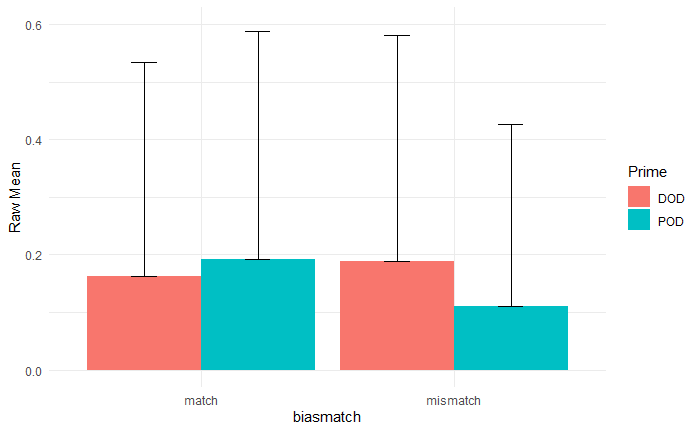

```r
(p1c <- DOD_42mo %>%
  filter(Overlap == "No Overlap") %>%
  group_by(Prime, biasmatch) %>%
  summarise(mean = mean(RESPONSE.CODE, na.rm=TRUE),
            sd = sd(RESPONSE.CODE, na.rm=TRUE)) %>%

ggplot(aes(y=mean, x=biasmatch, fill=Prime)) +
  geom_bar(stat="identity",position="dodge") +
 geom_errorbar(aes(ymin=mean, ymax=mean+sd), width=.2,
                 position=position_dodge(.9)) +
  ylim(0, .6) +
  theme_minimal() +
  labs(y="Raw Mean")
)
```

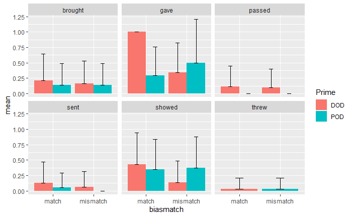

```r
DOD_42mo %>%
  filter(Overlap == "No Overlap") %>%
  group_by(Prime, biasmatch, Target.verb) %>%
  summarise(mean = mean(RESPONSE.CODE, na.rm=TRUE),
            sd = sd(RESPONSE.CODE, na.rm=TRUE)) %>%

ggplot(aes(y=mean, x=biasmatch, fill=Prime)) +
  geom_bar(stat="identity",position="dodge") +
 geom_errorbar(aes(ymin=mean, ymax=mean+sd), width=.2,
                 position=position_dodge(.9)) +
  facet_wrap(~Target.verb)
```

```r
DOD_42mo %>%
  filter(Overlap == "No Overlap") %>%
  group_by(Target.verb, Prime, biasmatch) %>%
  count()
```

| Target.verb | Prime | biasmatch | n |
| --- | --- | --- | --- |
| brought | DOD | match | 14 |
| brought | DOD | mismatch | 19 |
| brought | POD | match | 15 |
| brought | POD | mismatch | 15 |
| gave | DOD | match | 1 |
| gave | DOD | mismatch | 35 |
| gave | POD | match | 34 |
| gave | POD | mismatch | 2 |
| passed | DOD | match | 9 |
| passed | DOD | mismatch | 21 |

[output cut: 12 more lines]

```r
DOD_42mo %>%
   filter(Overlap == "No Overlap") %>%
   filter(Target.verb=="gave" & Prime=="DOD" & biasmatch == "match")
```

| Blind_ID | Gender | D.O.B. | Session.Date | Session.Age | Sess.Age.(Days) | Cond./List | Item | Prime.verb | Target.verb | Prime.Type | Verb.match | Verb.error | Verb.error_systematic | Admin.error | Repeat.prime | Repeat.target.prompt | Prime.interference | Missing.article | Pronoun | Prep.error | Prep.error.bin | Reversal.error | Prompts.allowable | Prompts.disallowed | NonTarget.response | No.response | Gave.POD | RESPONSE.CODE | Prime.code | … |
| --- | --- | --- | --- | --- | --- | --- | --- | --- | --- | --- | --- | --- | --- | --- | --- | --- | --- | --- | --- | --- | --- | --- | --- | --- | --- | --- | --- | --- | --- | --- |
| aOusW0Av | 1 | 2014-08-10 | 2018-03-02 | 42 : 20 | 1300 | 4 | 2r | brought | gave | 0.5 | -0.5 | 1 | NA | NA | NA | NA | NA | NA | NA | NA | NA | NA | NA | NA | NA | NA | NA | 1 | 1 | … |

```r
DOD_42mo %>%
   filter(Overlap == "No Overlap") %>%
   filter(Target.verb=="gave" & Prime=="POD" & biasmatch == "mismatch")
```

| Blind_ID | Gender | D.O.B. | Session.Date | Session.Age | Sess.Age.(Days) | Cond./List | Item | Prime.verb | Target.verb | Prime.Type | Verb.match | Verb.error | Verb.error_systematic | Admin.error | Repeat.prime | Repeat.target.prompt | Prime.interference | Missing.article | Pronoun | Prep.error | Prep.error.bin | Reversal.error | Prompts.allowable | Prompts.disallowed | NonTarget.response | No.response | Gave.POD | RESPONSE.CODE | Prime.code | … |
| --- | --- | --- | --- | --- | --- | --- | --- | --- | --- | --- | --- | --- | --- | --- | --- | --- | --- | --- | --- | --- | --- | --- | --- | --- | --- | --- | --- | --- | --- | --- |
| AUD17Yu2 | 0 | 2014-10-26 | 2018-05-17 | 42 : 21 | 1299 | 2 | 2r | brought | gave | -0.5 | -0.5 | 1 | NA | NA | NA | NA | NA | NA | NA | NA | NA | NA | NA | NA | NA | NA | NA | 0 | 1 | … |
| LkVZQCTn | 1 | 2015-09-23 | 2019-04-15 | 42 : 23 | 1300 | 5 | 5 | brought | gave | -0.5 | -0.5 | 1 | NA | NA | NA | NA | NA | NA | 1 | NA | NA | NA | NA | NA | NA | NA | NA | 1 | 0 | … |

# Lexical Boost

## All Participants

```r
logit_prior = prior(normal(0,2), class=sd)
```

```r
m0<- brm(RESPONSE.CODE ~ 1 + (1 | Blind_ID) + (1 | Target.verb),  family="bernoulli", prior=logit_prior, iter=4000, cores=4, data=DOD_42mo, file="42mo/output/m0.rds")
```

```r
m0b <- brm(RESPONSE.CODE ~ 1 + (1 | Blind_ID) + (1 | Target.verb) + (1 | Blind_ID:Target.verb),  family="bernoulli", prior=logit_prior, iter=4000, cores=4, data=DOD_42mo, file="42mo/output/m0b.rds")
```

Add loo for loo_compare

```r
m0<- add_criterion(m0, "loo")
m0b<- add_criterion(m0b, "loo")
```

```r
loo(m0, m0b, reloo=TRUE)
```

```
Output of model 'm0':

Computed from 8000 by 836 log-likelihood matrix
```

|  | Estimate | SE |
| --- | --- | --- |
| elpd_loo | -260.0 | 16.8 |
| p_loo | 50.7 | 4.2 |
| looic | 520.1 | 33.6 |

```
------
Monte Carlo SE of elpd_loo is NA.

Pareto k diagnostic values:
                         Count Pct.    Min. n_eff
(-Inf, 0.5]   (good)     832   99.5%   1986
 (0.5, 0.7]   (ok)         3    0.4%   928
   (0.7, 1]   (bad)        1    0.1%   916
   (1, Inf)   (very bad)   0    0.0%   <NA>
See help('pareto-k-diagnostic') for details.

Output of model 'm0b':

Computed from 8000 by 836 log-likelihood matrix
```

|  | Estimate | SE |
| --- | --- | --- |
| elpd_loo | -260.2 | 16.8 |
| p_loo | 62.8 | 5.1 |
| looic | 520.5 | 33.7 |

```
------
Monte Carlo SE of elpd_loo is 0.2.

Pareto k diagnostic values:
                         Count Pct.    Min. n_eff
(-Inf, 0.5]   (good)     820   98.1%   854
 (0.5, 0.7]   (ok)        16    1.9%   948
   (0.7, 1]   (bad)        0    0.0%   <NA>
   (1, Inf)   (very bad)   0    0.0%   <NA>

All Pareto k estimates are ok (k < 0.7).
See help('pareto-k-diagnostic') for details.

Model comparisons:
    elpd_diff se_diff
m0   0.0       0.0
m0b -0.2       0.7
```

```r
model_weights(m0, m0b)
```

```
       m0       m0b
0.8594549 0.1405451
```

Simpler model fits numerically better,

```r
m1 <- brm(RESPONSE.CODE ~ 1 + Prime.Type*Overlap  +  (1 +  Prime.Type*Overlap | Blind_ID) + (1 +  Prime.Type*Overlap   | Target.verb), logit_prior,family="bernoulli", cores=4, data=DOD_42mo, file="42mo/output/m1.rds")
```

```r
summary(m1)
```

```
 Family: bernoulli
  Links: mu = logit
Formula: RESPONSE.CODE ~ 1 + Prime.Type * Overlap + (1 + Prime.Type * Overlap | Blind_ID) + (1 + Prime.Type * Overlap | Target.verb)
   Data: DOD_42mo (Number of observations: 836)
Samples: 4 chains, each with iter = 2000; warmup = 1000; thin = 1;
         total post-warmup samples = 4000

Group-Level Effects:
~Blind_ID (Number of levels: 84)
                                              Estimate Est.Error l-95% CI u-95% CI Rhat Bulk_ESS Tail_ESS
sd(Intercept)                                     1.91      0.35     1.27     2.66 1.00     1604     2609
sd(Prime.Type)                                    1.04      0.58     0.07     2.24 1.00     1198     1926
sd(OverlapOverlap)                                0.68      0.50     0.02     1.82 1.00     1068     1979
sd(Prime.Type:OverlapOverlap)                     1.22      0.78     0.05     2.92 1.01     1288     2085
cor(Intercept,Prime.Type)                         0.16      0.37    -0.60     0.80 1.00     4628     3177
cor(Intercept,OverlapOverlap)                     0.30      0.42    -0.63     0.91 1.00     3786     2915
cor(Prime.Type,OverlapOverlap)                   -0.02      0.42    -0.80     0.78 1.00     2581     2379
cor(Intercept,Prime.Type:OverlapOverlap)          0.30      0.40    -0.60     0.89 1.00     4800     2506
cor(Prime.Type,Prime.Type:OverlapOverlap)         0.07      0.42    -0.74     0.80 1.00     3416     3014
cor(OverlapOverlap,Prime.Type:OverlapOverlap)     0.08      0.44    -0.76     0.85 1.00     3220     3064

~Target.verb (Number of levels: 6)
                                              Estimate Est.Error l-95% CI u-95% CI Rhat Bulk_ESS Tail_ESS
sd(Intercept)                                     1.95      0.68     0.96     3.59 1.00     3427     3244
sd(Prime.Type)                                    0.65      0.51     0.03     1.98 1.00     2411     2567
sd(OverlapOverlap)                                1.34      0.76     0.15     3.11 1.00     1917     1583
sd(Prime.Type:OverlapOverlap)                     1.06      0.76     0.06     2.86 1.00     2384     2400
cor(Intercept,Prime.Type)                        -0.20      0.43    -0.89     0.71 1.00     5950     2899
cor(Intercept,OverlapOverlap)                     0.10      0.37    -0.63     0.76 1.00     5285     3241
cor(Prime.Type,OverlapOverlap)                   -0.00      0.44    -0.80     0.80 1.00     2761     3071
cor(Intercept,Prime.Type:OverlapOverlap)         -0.12      0.43    -0.84     0.73 1.00     6917     2592
cor(Prime.Type,Prime.Type:OverlapOverlap)        -0.00      0.45    -0.79     0.82 1.00     4205     2984
cor(OverlapOverlap,Prime.Type:OverlapOverlap)     0.07      0.44    -0.76     0.84 1.00     3467     3420

Population-Level Effects:
                          Estimate Est.Error l-95% CI u-95% CI Rhat Bulk_ESS Tail_ESS
Intercept                    -2.77      0.90    -4.58    -0.94 1.00     2132     2574
Prime.Type                    0.47      0.60    -0.72     1.69 1.00     3857     3030
OverlapOverlap               -1.00      0.84    -2.86     0.53 1.00     2419     2489
Prime.Type:OverlapOverlap     1.20      1.00    -0.68     3.24 1.00     3256     2843

Samples were drawn using sampling(NUTS). For each parameter, Bulk_ESS
and Tail_ESS are effective sample size measures, and Rhat is the potential
scale reduction factor on split chains (at convergence, Rhat = 1).
```

```r
hypothesis(m1, "Prime.Type > 0")
```

```
Hypothesis Tests for class b:
```

| Hypothesis | Estimate | Est.Error | CI.Lower | CI.Upper | Evid.Ratio | Post.Prob | Star |
| --- | --- | --- | --- | --- | --- | --- | --- |
| (Prime.Type) > 0 | 0.47 | 0.6 | -0.49 | 1.46 | 3.92 | 0.8 |  |

```
---
'CI': 90%-CI for one-sided and 95%-CI for two-sided hypotheses.
'*': For one-sided hypotheses, the posterior probability exceeds 95%;
for two-sided hypotheses, the value tested against lies outside the 95%-CI.
Posterior probabilities of point hypotheses assume equal prior probabilities.
```

```r
hypothesis(m1, "Prime.Type:OverlapOverlap > 0")
```

```
Hypothesis Tests for class b:
```

| Hypothesis | Estimate | Est.Error | CI.Lower | CI.Upper | Evid.Ratio | Post.Prob | Star |
| --- | --- | --- | --- | --- | --- | --- | --- |
| (Prime.Type:Overl... > 0 | 1.2 | 1 | -0.37 | 2.86 | 8.39 | 0.89 |  |

```
---
'CI': 90%-CI for one-sided and 95%-CI for two-sided hypotheses.
'*': For one-sided hypotheses, the posterior probability exceeds 95%;
for two-sided hypotheses, the value tested against lies outside the 95%-CI.
Posterior probabilities of point hypotheses assume equal prior probabilities.
```

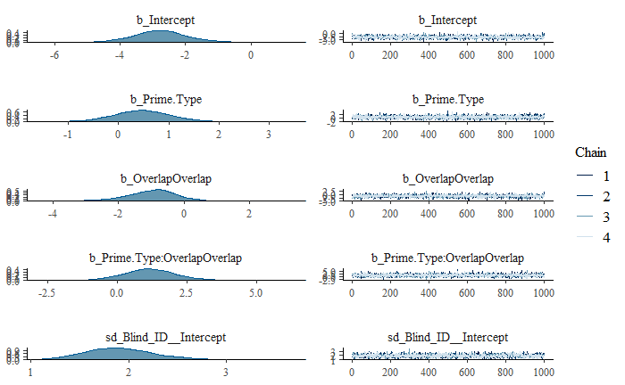

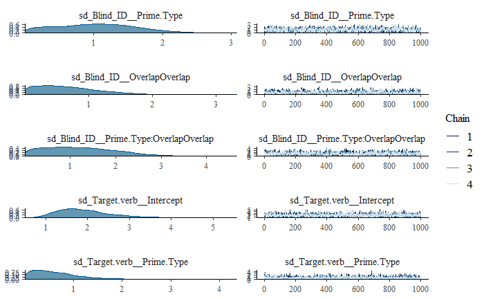

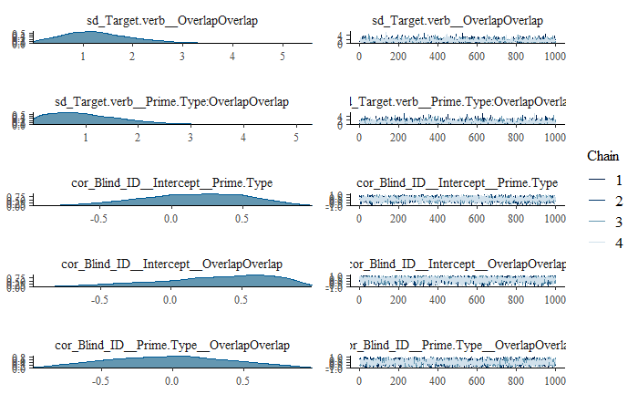

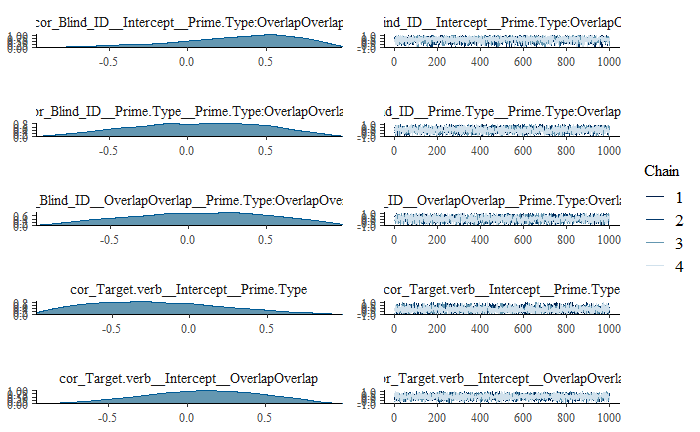

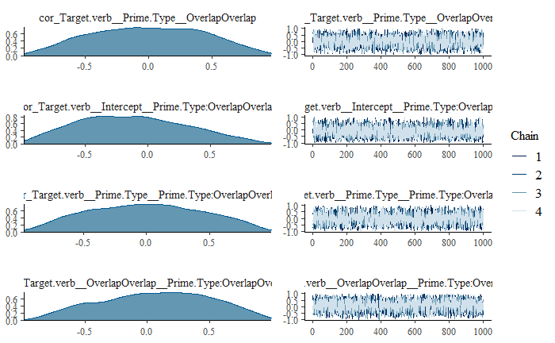

```r
plot(m1)
```

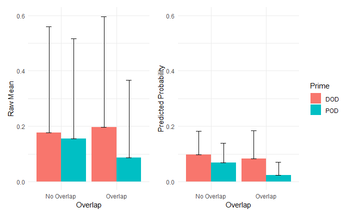

```r
p2 <- fitted(m1, re_formula=NA, scale="response") %>%
  cbind(DOD_42mo) %>%
  dplyr::select(Prime, Overlap, Estimate, Est.Error) %>%
  ggplot(aes(y=Estimate, x=Overlap, fill=Prime )) +
  geom_bar(stat="identity",position="dodge") +
  geom_errorbar(aes(ymin=Estimate, ymax=Estimate+Est.Error), width=.2,
                 position=position_dodge(.9)) +
  theme_minimal() +
  ylim(0, .6) +
  labs(y="Predicted Probability") +
  theme(legend.position = "none")


p1 | p2 + plot_layout(guides = "collect") & theme(legend.position = "right")
```

```r
library("tidybayes")
ps_means1 <- posterior_samples(m1) %>%
  dplyr::select(Intc = "b_Intercept", Prime = "b_Prime.Type", Overlap= "b_OverlapOverlap", Int = "b_Prime.Type:OverlapOverlap") %>%
  mutate(
    DOD_no = inv_logit_scaled(Intc + .5*Prime),
    POD_no = inv_logit_scaled(Intc  - .5*Prime),
    RR_ap = DOD_no/POD_no,
    DOD_o = inv_logit_scaled(Intc + .5*Prime + Overlap + .5*Int),
    POD_o = inv_logit_scaled(Intc - .5*Prime + Overlap - .5*Int),
    RR_ov = (DOD_o/POD_o)
  ) %>%
  dplyr::select(RR_ap, RR_ov) %>%
  pivot_longer(everything(), names_to = "RR", values_to = "value") %>%
  mutate(
    Effect = ifelse(RR=="RR_ap", yes= "Abstract Priming", no="Lexically Boosted Priming")
  )

ps_means1 %>%
  group_by(Effect) %>%
  dplyr::select(-"RR") %>%
  mean_hdi()
```

| Effect | value | .lower | .upper | .width | .point | .interval |
| --- | --- | --- | --- | --- | --- | --- |
| Abstract Priming | 1.835723 | 0.2777710 | 3.965583 | 0.95 | mean | hdi |
| Lexically Boosted Priming | 8.765252 | 0.1778712 | 24.588464 | 0.95 | mean | hdi |

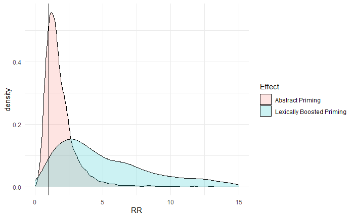

```r
RR1 <- ggplot(ps_means1, aes(x=value, fill=Effect)) + geom_density(alpha = .2) + xlim(0, 15) + geom_vline(xintercept=1) + theme_minimal() + xlab("RR")

RR1
```

## Grammatical Only

```r
m2 <- brm(RESPONSE.CODE ~ 1 + Prime.Type*Overlap  +  (1 +  Prime.Type*Overlap | Blind_ID) + (1 +  Prime.Type*Overlap   | Target.verb), logit_prior,family="bernoulli", cores=4, data=DOD_42mo2, file="42mo/output/m2.rds")
```

```r
hypothesis(m2, "Prime.Type > 0")
```

```
Hypothesis Tests for class b:
```

| Hypothesis | Estimate | Est.Error | CI.Lower | CI.Upper | Evid.Ratio | Post.Prob | Star |
| --- | --- | --- | --- | --- | --- | --- | --- |
| (Prime.Type) > 0 | 0.65 | 0.59 | -0.28 | 1.65 | 7.2 | 0.88 |  |

```
---
'CI': 90%-CI for one-sided and 95%-CI for two-sided hypotheses.
'*': For one-sided hypotheses, the posterior probability exceeds 95%;
for two-sided hypotheses, the value tested against lies outside the 95%-CI.
Posterior probabilities of point hypotheses assume equal prior probabilities.
```

```r
hypothesis(m2, "Prime.Type:OverlapOverlap > 0")
```

```
Hypothesis Tests for class b:
```

| Hypothesis | Estimate | Est.Error | CI.Lower | CI.Upper | Evid.Ratio | Post.Prob | Star |
| --- | --- | --- | --- | --- | --- | --- | --- |
| (Prime.Type:Overl... > 0 | 1.57 | 0.89 | 0.15 | 3.05 | 27.37 | 0.96 | * |

```
---
'CI': 90%-CI for one-sided and 95%-CI for two-sided hypotheses.
'*': For one-sided hypotheses, the posterior probability exceeds 95%;
for two-sided hypotheses, the value tested against lies outside the 95%-CI.
Posterior probabilities of point hypotheses assume equal prior probabilities.
```

```r
p2 <- fitted(m2, re_formula=NA, scale="response") %>%
  cbind(DOD_42mo2) %>%
  dplyr::select(Prime, Overlap, Estimate, Est.Error) %>%
  ggplot(aes(y=Estimate, x=Overlap, fill=Prime )) +
  geom_bar(stat="identity",position="dodge") +
  geom_errorbar(aes(ymin=Estimate, ymax=Estimate+Est.Error), width=.2,
                 position=position_dodge(.9)) +
  theme_minimal() +
  ylim(0, .9) +
  labs(y="Predicted Probability") +
  theme(legend.position = "none")


p1b | p2 + plot_layout(guides = "collect") & theme(legend.position = "right")
```

[output not shown]

```r
ps_means2 <- posterior_samples(m2) %>%
  dplyr::select(Intc = "b_Intercept", Prime = "b_Prime.Type", Overlap= "b_OverlapOverlap", Int = "b_Prime.Type:OverlapOverlap") %>%
  mutate(
    DOD_no = inv_logit_scaled(Intc + .5*Prime),
    POD_no = inv_logit_scaled(Intc  - .5*Prime),
    RR_ap = DOD_no/POD_no,
    DOD_o = inv_logit_scaled(Intc + .5*Prime + Overlap + .5*Int),
    POD_o = inv_logit_scaled(Intc - .5*Prime + Overlap - .5*Int),
    RR_ov = (DOD_o/POD_o)
  ) %>%
  dplyr::select(RR_ap, RR_ov) %>%
  pivot_longer(everything(), names_to = "RR", values_to = "value") %>%
  mutate(
    Effect = ifelse(RR=="RR_ap", yes= "Abstract Priming", no="Lexically Boosted Priming")
  )

ps_means2 %>%
  group_by(Effect) %>%
  dplyr::select(-"RR") %>%
  mean_hdi()

RR2 <- ggplot(ps_means2, aes(x=value, fill=Effect)) + geom_density(alpha = .2) + xlim(0, 15) + geom_vline(xintercept=1) + theme_minimal() + xlab("RR")

RR2
```

[output not shown]

```r
tab_model(m1, m2, show.re.var=FALSE, show.r2=FALSE, show.icc=FALSE, transform=NULL, collapse.ci=TRUE, p.style="scientific", ci.hyphen = " : ", dv.labels=c("Model 1",  "Model 2"), string.stat="",
          pred.labels=c(
            "Intercept",
            "Prime (DOD)",
            "Overlap",
            "Prime * Overlap"
          ))
```

# Bias Mismatch

```r
DOD_42mo3 <- filter(DOD_42mo, Overlap=="No Overlap")
m3 <- brm(RESPONSE.CODE ~ 1 +Prime.Type*biasmatch + (1 + Prime.Type*biasmatch| Blind_ID) + (1 + Prime.Type*biasmatch| Target.verb), logit_prior, family="bernoulli", iter=4000, cores=4, file="42mo/output/m3.rds", data=DOD_42mo3)
summary(m3)
m3 <- add_criterion(m3, "loo")
```

```r
plot(m3)
```

```r
hypothesis(m3, "Prime.Type > 0")
hypothesis(m3, "Prime.Type:biasmatchmismatch > 0") # Bias mismatch
```

```r
DOD_42mo3 %>%
  mutate(
    k = m3$criteria$loo$diagnostics$pareto_k
  ) %>%
  ggplot(aes(x=k)) + geom_histogram()

DOD_42mo3 %>%
  mutate(
    k = m3$criteria$loo$diagnostics$pareto_k
  ) %>%
  filter(k >= .7)
```

```r
m3b <- DOD_42mo3 %>%
  mutate(
    k = m3$criteria$loo$diagnostics$pareto_k
  ) %>%
  filter(k < .7) %>%
 brm(RESPONSE.CODE ~ 1 +Prime.Type*biasmatch + (1 +Prime.Type*biasmatch  | Blind_ID) + (1 +Prime.Type*biasmatch | Target.verb), logit_prior, family="bernoulli", iter=4000, cores=4, file="42mo/output/m3b.rds", data=.)
```

```r
summary(m3b)

hypothesis(m3b, "Prime.Type > 0")
hypothesis(m3b, "Prime.Type:biasmatchmismatch > 0") # Bias mismatch
```

```r
p3 <- fitted(m3, re_formula=NA, scale="response") %>%
  cbind(DOD_42mo3) %>%
  dplyr::select(Prime, biasmatch, Estimate, Est.Error) %>%
  ggplot(aes(y=Estimate, x=biasmatch, fill=Prime )) +
  geom_bar(stat="identity",position="dodge") +
  geom_errorbar(aes(ymin=Estimate, ymax=Estimate+Est.Error), width=.2,
                 position=position_dodge(.9)) +
  theme_minimal() +
  ylim(0, .6) +
  labs(y="Predicted Probability") +
  theme(legend.position = "none")


p1c | p3 + plot_layout(guides = "collect") & theme(legend.position = "right")
```

```r
DOD_42mo4 <-
  DOD_42mo3 %>%
  filter(Prod_DOD > 0)
```

```r
m4 <- brm(RESPONSE.CODE ~ 1 +Prime.Type*biasmatch + (1 + Prime.Type*biasmatch| Blind_ID) + (1 + Prime.Type*biasmatch| Target.verb), logit_prior, family="bernoulli", iter=4000, cores=4, file="42mo/output/m4.rds", data=DOD_42mo4)
summary(m4)
m4 <- add_criterion(m4, "loo")
```

```r
hypothesis(m4, "Prime.Type > 0")
hypothesis(m4, "Prime.Type:biasmatchmismatch > 0") # Bias mismatch
```

```r
DOD_42mo4 %>%
  mutate(
    k = m4$criteria$loo$diagnostics$pareto_k
  ) %>%
  ggplot(aes(x=k)) + geom_histogram()

DOD_42mo4 %>%
  mutate(
    k = m4$criteria$loo$diagnostics$pareto_k
  ) %>%
  filter(k >= .7)
```

```r
m4b <- DOD_42mo4 %>%
  mutate(
    k = m4$criteria$loo$diagnostics$pareto_k
  ) %>%
  filter(k < .7) %>%
 brm(RESPONSE.CODE ~ 1 +Prime.Type*biasmatch + (1 +Prime.Type*biasmatch  | Blind_ID) + (1 +Prime.Type*biasmatch | Target.verb), logit_prior, family="bernoulli", iter=4000, cores=4, file="42mo/output/m4b.rds", data=.)
```

```r
summary(m4b)
hypothesis(m4b, "Prime.Type > 0")
hypothesis(m4b, "Prime.Type:biasmatchmismatch > 0") # Bias mismatch
```

```r
tab_model(m1, m2, m3, m4, show.re.var=FALSE, show.r2=FALSE, show.icc=FALSE, transform=NULL, collapse.ci=TRUE, p.style="scientific", ci.hyphen = " : ", dv.labels=c("Model 1",  "Model 2", "Model 3", "Model 4"), string.stat="", file="Table4",
           pred.labels=c(
            "Intercept",
            "Prime (DOD)",
            "Overlap",
            "Prime * Overlap",
            "Bias Mismatch (POD)",
            "Prime * Bias Mismatch "
          ))
```